# Object-oriented scientific programming with C++

# Example

Compute the sum of the entries of an array

```
double sum(const int* array, int length) {

    double s = 0;

    for (auto i=0; i<length; i++)
        s += array[i];

    return s;
}

int array[5] = { 1, 2, 3, 4, 5 };
std::cout << sum(array, 5) << std::endl;
```

```
15
```

This is not OOP. DON'T, REALLY DON'T DO THIS IN C++! We will learn much better ways to pass bigger objects such as arrays by (constant) reference.

There is one exception. If you want to allocate memory dynamically inside the function and assign it to a variable defined outside the function you need to work with double pointers.

# Static arrays

Definition and creation of a static array

```
int array[5];
```

Definition, creation and initialization of a static array

```
int array[5] = { 1, 2, 3, 4, 5 }; // since C++11
int array[5]{ 1, 2, 3, 4, 5 }; // since C++11</pre>
```

Access of individual array positions

```
for (auto i=0; i<5; i++)
    std::cout << array[i] << std::endl;
```

```
1
2
3
4
5
```

Remember that C++ **starts indexing at 0**

Static arrays are **destroyed automatically** at the end of scope

# Quiz: Static arrays

What happens?

```
auto array = { 1, 2, 3, 4, 5 };
```

```
auto array{ 1, 2, 3, 4, 5 };
```

# Quiz: char* argv[]

What is char* argv[]?

Example use case:

```
main(int argc, char* argv[]) {
     for (int i=0; i<argc; i++)
        std::cout << i << “-Argument is “ << argv[i] << “\n”;
}
```

# Dynamic arrays

- Definition and allocation of dynamic array

  ```
   int* array = new int[5];
  ```

- Definition, allocation and initialization of dynamic array

  ```
  int* array = new int[5]{ 1, 2, 3, 4, 5 }; // in C++11
  ```

- Explicit deallocation of dynamically allocated array needed

  ```
  delete[] array;
  ```

- Think fail-safe! Because it still points to an invalid address

  ```
  array = nullptr;
  ```

# Example of a dynamic array

```
int* array = new int[5]{ 1, 2, 3, 4, 5 };

for (auto i=0; i<5; i++)
    std::cout << array[i] << std::endl;

delete[] array;
array = nullptr;
```

```
1
2
3
4
5
```

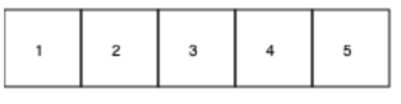

# Static vs. dynamic arrays

Static arrays require the size to be known at compile time

```
int array[5];
constexpr int k=5; // constexpr tells the compiler that the
int array[k];      // expression is available at compile time
int k=5;
int array[k];      // Gives a compiler error !!!
```

Dynamic arrays allow variable sizes at run-time

```
int k = std::atoi(argv[1]);
int* array = new int[k];
```

[figure not shown]

# Namespaces

Namespaces, like `std`, allow to bundle functions even with the same function name (and interface) into logical units

```
namespace tudelft {
    void hello() {
      std::cout << “Hello TU Delft\n”;
    }
}
```

```
namespace other {
    void hello() {
      std::cout << “Hello other\n”;
    }
}
```

Functions implemented in a namespace can be called by

- providing the namespace explicitly

  ```
  tudelft::hello();
  other::hello();
  ```

- importing the namespace into the scope

  ```
  {
    using namespace tudelft;
    hello();
  }

  {
    using namespace other;
    hello();
  }
  ```

Namespaces can be nested

```
namespace tudelft {
    void hello() { std::cout << "Hello TU Delft\n"; }
    namespace eemcs {
      void hello() { std::cout << "Hello EEMCS\n"; }
    }
}

tudelft::hello();
tudelft::eemcs::hello();
```

Leading :: goes back to outermost unnamed namespace

```
namespace tudelft {
    void hello() { ::hello();
                   std::cout << "TU Delft\n"; }
    namespace eemcs {
      void hello() { ::hello();
  std::cout << "EEMCS at";
  ::tudelft::hello();
            }
    }
}

void hello() { std::cout << "Hello "; }
```